First, let us load the data and necessary packages:

```r
load("ames_train.Rdata")
library(ggplot2)
library(dplyr)
library(statsr)
library(BAS)
library(GGally)
library("gplots")
library(gridExtra)
library(grid)
library(plotmo)
library(MASS)
library(tidyverse)
library(broom)
options(width=100)
```

# 1

Make a labeled histogram (with 30 bins) of the ages of the houses in the data set, and describe the distribution.

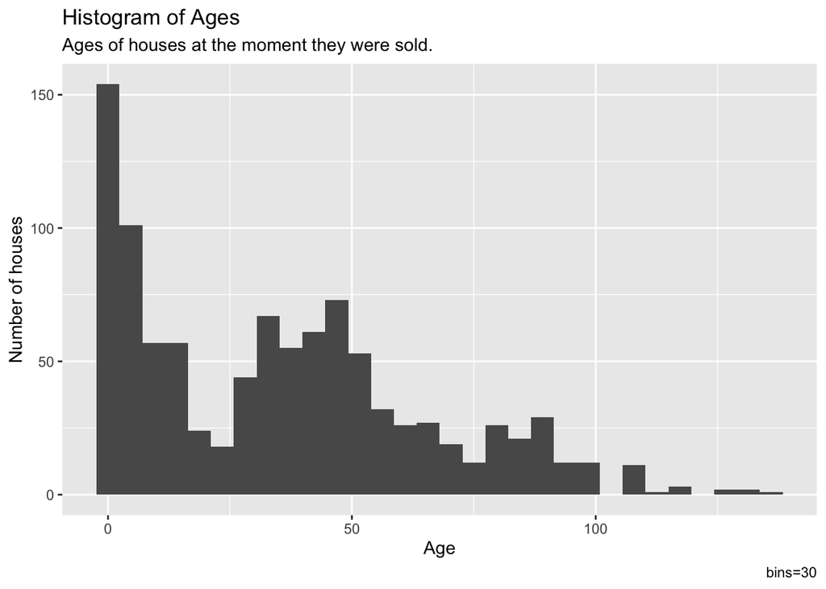

```r
# Age is defined by the year when it was sold (we tracked that price) minus the year it was built
ames_train$age_when_sold <- ames_train$Yr.Sold - ames_train$Year.Built
ggplot(data = ames_train, mapping = aes(x=age_when_sold)) + geom_histogram(bins = 30) + labs(title = "Histogram of Ages", subtitle = "Ages of houses at the moment they were sold.", caption = "bins=30") + xlab("Age") + ylab("Number of houses")
```

```r
summary(ames_train$age_when_sold)
```

```
##    Min. 1st Qu.  Median    Mean 3rd Qu.    Max.
##    0.00    7.00   33.00   35.56   52.00  136.00
```

Many houses were sold when they were new and many when they were around 30 to 50 years old. The age distribution seems to be bi- or tri-modal and right-skewed. The houses ages vary from 0 to 136 years. Basic statistics are shown above.

# 2

The mantra in real estate is “Location, Location, Location!” Make a graphical display that relates a home price to its neighborhood in Ames, Iowa. Which summary statistics are most appropriate to use for determining the most expensive, least expensive, and most heterogeneous (having the most variation in housing price) neighborhoods? Report which neighborhoods these are based on the summary statistics of your choice. Report the value of your chosen summary statistics for these neighborhoods.

```r
# type your code for Question 2 here, and Knit
summary(ames_train$Neighborhood)
```

```
## Blmngtn Blueste  BrDale BrkSide ClearCr CollgCr Crawfor Edwards Gilbert  Greens GrnHill  IDOTRR
##      11       3      10      41      13      85      29      60      49       4       2      35
## Landmrk MeadowV Mitchel   NAmes NoRidge NPkVill NridgHt  NWAmes OldTown  Sawyer SawyerW Somerst
##       0      16      44     155      28       4      57      41      71      61      46      74
## StoneBr   SWISU  Timber Veenker
##      20      12      19      10
```

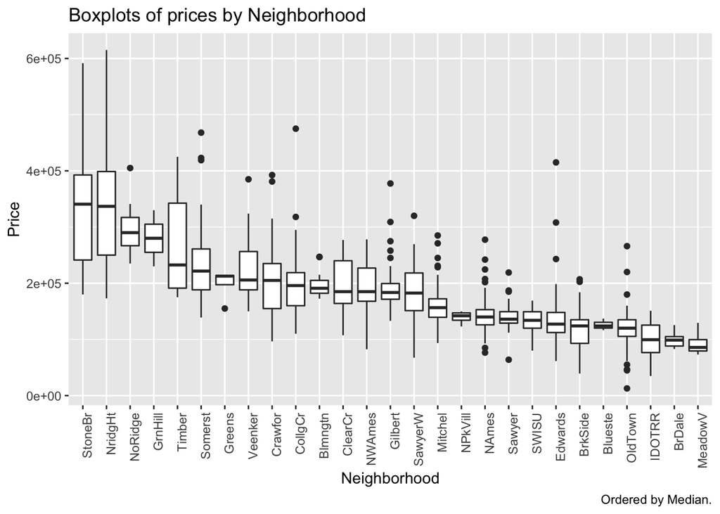

```r
ggplot(ames_train, aes(x=reorder(Neighborhood, -price, FUN = median), y=price)) + geom_boxplot()  + labs(title = "Boxplots of prices by Neighborhood", caption = "Ordered by Median.") + xlab("Neighborhood") + ylab("Price") + theme(axis.text.x = element_text(angle = 90, hjust = 1))
```

```r
# Most expensive neighborhood
ames_train %>% group_by(Neighborhood) %>% summarise(Median=median(price)) %>% filter(Median>=max(Median))
```

```
## # A tibble: 1 x 2
##   Neighborhood  Median
##   <fct>          <dbl>
## 1 StoneBr      340692.
```

```r
# Least expensive neighborhood
ames_train %>% group_by(Neighborhood) %>% summarise(Median=median(price)) %>% filter(Median<=min(Median))
```

```
## # A tibble: 1 x 2
##   Neighborhood Median
##   <fct>         <dbl>
## 1 MeadowV       85750
```

```r
# Most heterogeneous neighborhood
ames_train %>% group_by(Neighborhood) %>% summarise(SD=sd(price)) %>% filter(SD>=max(SD))
```

```
## # A tibble: 1 x 2
##   Neighborhood      SD
##   <fct>          <dbl>
## 1 StoneBr      123459.
```

The appropriate summary statistic for determining a price for a neighborhood is the Median, once there are many price distributions that are right or left skewed. We also have a considerable large numbre of outliers, therefore it is appropriate to use SD over IQR as a summary statistic to find the one with the most variation. These are the neighborhoods considered the:

- *most expensive*: StoneBR has median price 340,691.5;
- *least expensive*: MeadowV has median price 85,750;
- *most heterogeneous*: StoneBr has SD equals to 123,459.1.

# 3

Which variable has the largest number of missing values? Explain why it makes sense that there are so many missing values for this variable.

```r
# type your code for Question 3 here, and Knit
ames_train %>%
  select_if(function(x) any(is.na(x))) %>%
  summarise_each(funs(sum(is.na(.)))) -> extra_NA
ames_train %>% filter(Pool.Area > 0) %>% count()
```

```
## # A tibble: 1 x 1
##       n
##   <int>
## 1     3
```

```r
ames_train %>% count()
```

```
## # A tibble: 1 x 1
##       n
##   <int>
## 1  1000
```

```r
d <- t(extra_NA)
d[order(-d),]
```

```
##        Pool.QC   Misc.Feature          Alley          Fence   Fireplace.Qu   Lot.Frontage
##            997            971            933            798            491            167
##  Garage.Yr.Blt    Garage.Qual    Garage.Cond    Garage.Type  Garage.Finish      Bsmt.Qual
##             48             47             47             46             46             21
##      Bsmt.Cond  Bsmt.Exposure BsmtFin.Type.1 BsmtFin.Type.2   Mas.Vnr.Area   BsmtFin.SF.1
##             21             21             21             21              7              1
##   BsmtFin.SF.2    Bsmt.Unf.SF  Total.Bsmt.SF Bsmt.Full.Bath Bsmt.Half.Bath    Garage.Cars
##              1              1              1              1              1              1
##    Garage.Area
##              1
```

The variable **Pool.QC** indicates pool quality and has the largest number of NAs because **there are only three houses with pools**. That is, the 997 houses with NA for Pool.QC is explained by the only three houses with pools (1000-3).

# 4

We want to predict the natural log of the home prices. Candidate explanatory variables are lot size in square feet (Lot.Area), slope of property (Land.Slope), original construction date (Year.Built), remodel date (Year.Remod.Add), and the number of bedrooms above grade (Bedroom.AbvGr). Pick a model selection or model averaging method covered in the Specialization, and describe how this method works. Then, use this method to find the best multiple regression model for predicting the natural log of the home prices.

```r
# type your code for Question 4 here, and Knit
#ames_train <- na.omit(ames_train)
ames_train$price_log <- log(ames_train$price)
fit1 <- lm(price_log ~ Lot.Area + Land.Slope + Year.Built + Year.Remod.Add + Bedroom.AbvGr, ames_train, na.action = na.omit)
# To use BIC in the stepAIC, change "k=2" to "k=log(n)"
fit2 <- stepAIC(fit1, k=log(nrow(ames_train)), trace = FALSE)
anova(fit2)
```

```
## Analysis of Variance Table
##
## Response: price_log
##                 Df Sum Sq Mean Sq F value    Pr(>F)
## Lot.Area         1 10.392  10.392 133.462 < 2.2e-16 ***
## Land.Slope       2  2.424   1.212  15.564 2.211e-07 ***
## Year.Built       1 68.991  68.991 886.012 < 2.2e-16 ***
## Year.Remod.Add   1 12.535  12.535 160.982 < 2.2e-16 ***
## Bedroom.AbvGr    1  5.063   5.063  65.018 2.124e-15 ***
## Residuals      993 77.322   0.078
## ---
## Signif. codes:  0 '***' 0.001 '**' 0.01 '*' 0.05 '.' 0.1 ' ' 1
```

```r
# plot(fit)
summary(fit2)
```

```
##
## Call:
## lm(formula = price_log ~ Lot.Area + Land.Slope + Year.Built +
##     Year.Remod.Add + Bedroom.AbvGr, data = ames_train, na.action = na.omit)
##
## Residuals:
##     Min      1Q  Median      3Q     Max
## -2.0878 -0.1651 -0.0211  0.1657  0.9945
##
## Coefficients:
##                  Estimate Std. Error t value Pr(>|t|)
## (Intercept)    -1.371e+01  8.574e-01 -15.996  < 2e-16 ***
## Lot.Area        1.028e-05  1.106e-06   9.296  < 2e-16 ***
## Land.SlopeMod   1.384e-01  4.991e-02   2.773  0.00565 **
## Land.SlopeSev  -4.567e-01  1.514e-01  -3.016  0.00263 **
## Year.Built      6.049e-03  3.788e-04  15.968  < 2e-16 ***
## Year.Remod.Add  6.778e-03  5.468e-04  12.395  < 2e-16 ***
## Bedroom.AbvGr   8.686e-02  1.077e-02   8.063 2.12e-15 ***
## ---
## Signif. codes:  0 '***' 0.001 '**' 0.01 '*' 0.05 '.' 0.1 ' ' 1
##
## Residual standard error: 0.279 on 993 degrees of freedom
## Multiple R-squared:  0.5625, Adjusted R-squared:  0.5598
## F-statistic: 212.8 on 6 and 993 DF,  p-value: < 2.2e-16
```

```r
BIC(fit2)
```

```
## [1] 333.3642
```

```r
confint(fit2)
```

```
##                        2.5 %        97.5 %
## (Intercept)    -1.539676e+01 -1.203189e+01
## Lot.Area        8.108705e-06  1.244810e-05
## Land.SlopeMod   4.048525e-02  2.363856e-01
## Land.SlopeSev  -7.539047e-01 -1.595778e-01
## Year.Built      5.305779e-03  6.792573e-03
## Year.Remod.Add  5.705098e-03  7.851227e-03
## Bedroom.AbvGr   6.572328e-02  1.080024e-01
```

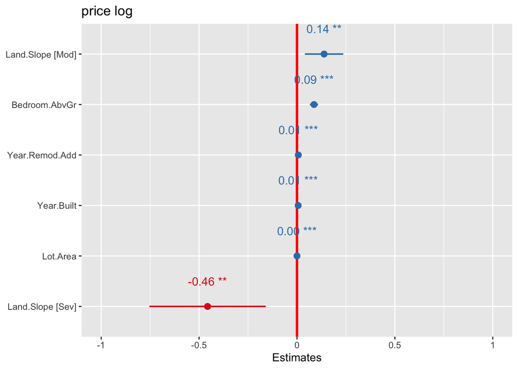

```r
library(sjPlot)
plot_model(fit2, vline.color = "red", sort.est = TRUE, show.values = TRUE, value.offset = .5)
```

By using a stepwise model selection stepAIC with BIC criteria (k=log(n) instead of k=2) we seek for the model with the lowest BIC value. In the normal stepAIC, we seek for the lowest AIC value. Here, to use BIC criteria, we change the value k=2 to k=log(n); that is, in the function stepAIC(…, k=2) we now have stepAIC(…, k=log(n)).

The model selection approach stepAIC starts with a full model (or null model) and remove feature by feature and check if the AIC/BIC was reduced in the new model. In the first loop, if we have K features, we will have models with k-1 features. If AIC was reduced, we go to the next loop, where we will have models with k-2 features, and so on. We stop when AIC/BIC does not change anymore.

In our case, we have as result:

- **Initial Model**: log(price) ~ Lot.Area + Land.Slope + Year.Built + Year.Remod.Add + Bedroom.AbvGr
- **Final Model**: log(price) ~ Lot.Area + Land.Slope + Year.Built + Year.Remod.Add + Bedroom.AbvGr

# 5

Which home has the largest squared residual in the previous analysis (Question 4)? Looking at all the variables in the data set, can you explain why this home stands out from the rest (what factors contribute to the high squared residual and why are those factors relevant)?

```r
# type your code for Question 5 here, and Knit
# Standardize residuals
ames_train$stdres <- stdres(fit2)
ames_train$stdres_abs <- abs(stdres(fit2))
# The largest residual or squared residual is by definition the same:
ames_train$stdres_gt3 <- abs(stdres(fit2)) > 3  #getting what is above 3 std
ames_train$predicted <-  predict(fit2)
ames_train$squared_res <-  residuals(fit2)^2
ames_train[which(ames_train$stdres_gt3 == TRUE), c('PID','Lot.Area','Land.Slope', 'Year.Built','Year.Remod.Add','Bedroom.AbvGr', 'stdres_abs', 'stdres', 'squared_res', 'price', 'price_log', 'predicted')] %>% arrange(desc(stdres_abs)) %>% head(n=5)
```

```
## # A tibble: 5 x 12
##      PID Lot.Area Land.Slope Year.Built Year.Remod.Add Bedroom.AbvGr stdres_abs stdres squared_res
##    <int>    <int> <fct>           <int>          <int>         <int>      <dbl>  <dbl>       <dbl>
## 1 9.02e8     9656 Gtl              1923           1970             2       7.50  -7.50       4.36
## 2 5.34e8    13260 Gtl              1962           2001             6       3.71  -3.71       1.05
## 3 5.28e8    12720 Mod              2003           2003             1       3.63   3.63       0.989
## 4 9.11e8     9000 Gtl              1949           1950             1       3.60  -3.60       1.00
## 5 5.34e8     5000 Mod              1946           1950             1       3.55  -3.55       0.946
## # … with 3 more variables: price <int>, price_log <dbl>, predicted <dbl>
```

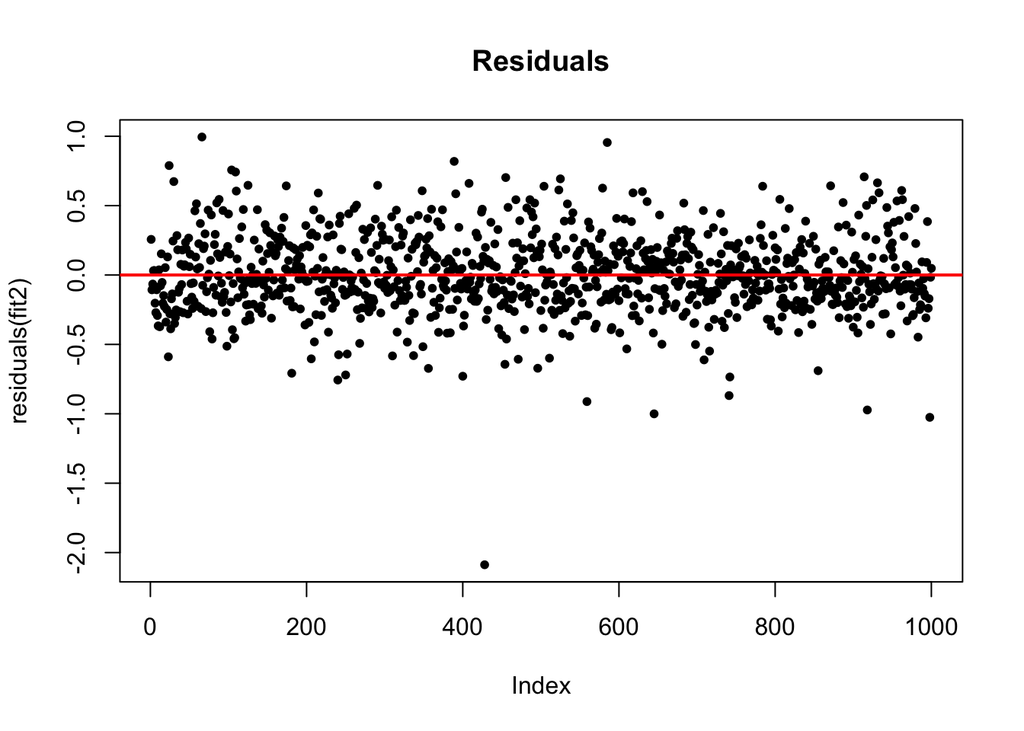

```r
plot(residuals(fit2), main="Residuals",pch=20)
abline(0,0, lwd=2, col="red")
```

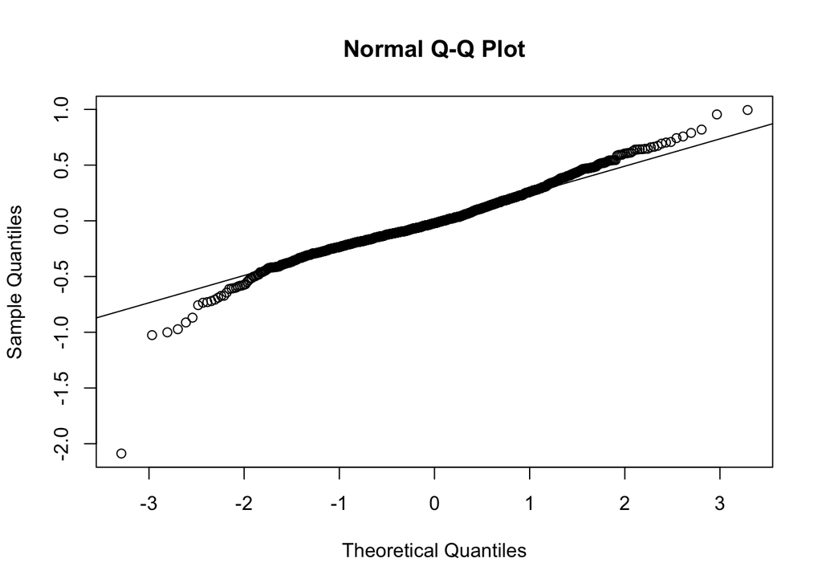

```r
qqnorm(residuals(fit2))
qqline(residuals(fit2))
```

```r
#ames_train[which(ames_train$PID == 902207130),]
#ames_train[which(ames_train$stdres_gt3 == TRUE), c('Bedroom.AbvGr','Overall.Qual', 'Year.Built','Sale.Condition','stdres_abs')] %>% arrange(desc(stdres_abs)) %>% head(n=3)
```

The house with the largest squared residual is the one with PID 902207130. This house has the residual over 3 times the Standard Deviation and, hence, can be considered an outlier. In fact, this house has the smallest price of 12,789, being the second smallest price of 30,900. By the price we can see that this must be a house of bad quality. In fact, the quality has score equals to 2, very low.

Hence, factors that are not in the model fit2 also contributed to the price to be very far from the mean and median, what makes it to have the largest squared residual. Examples of factors are: * the age of the house, since it is a very old house (**Year built**: 1923); * the year when it was Remodeled (**Remodel date**: 1970); * the quality (**Quality**: 2); * and others.

There are attributes in our model that makes the fitted curve to be far from the outlier value, such as the Bedroom.AbvGr, Land.Slope and Lot.Area. These attributes, when “low/not that good”, they tend to have a price near to 30,000, not near to 12,000. Therefore, the model created brings this largest residual to this case which is very different from most of the houses in very heavy attributes such as the year and house quality.

# 6

Use the same model selection method you chose in Question 4 to again find the best multiple regression model to predict the natural log of home prices, but this time **replacing Lot.Area with log(Lot.Area)**. Do you arrive at a model including the same set of predictors?

```r
# type your code for Question 6 here, and Knit
fit3 <- lm(price_log ~ log(Lot.Area) + Land.Slope + Year.Built + Year.Remod.Add + Bedroom.AbvGr, ames_train, na.action = na.omit)
# To use BIC in the stepAIC, change "k=2" to "k=log(n)"
fit4 <- stepAIC(fit3, k=log(nrow(ames_train)), trace = FALSE)
anova(fit4)
```

```
## Analysis of Variance Table
##
## Response: price_log
##                 Df Sum Sq Mean Sq F value    Pr(>F)
## log(Lot.Area)    1 24.338  24.338 345.224 < 2.2e-16 ***
## Year.Built       1 67.894  67.894 963.045 < 2.2e-16 ***
## Year.Remod.Add   1 12.267  12.267 174.000 < 2.2e-16 ***
## Bedroom.AbvGr    1  2.082   2.082  29.526 6.939e-08 ***
## Residuals      995 70.147   0.070
## ---
## Signif. codes:  0 '***' 0.001 '**' 0.01 '*' 0.05 '.' 0.1 ' ' 1
```

```r
# plot(fit)
summary(fit4)
```

```
##
## Call:
## lm(formula = price_log ~ log(Lot.Area) + Year.Built + Year.Remod.Add +
##     Bedroom.AbvGr, data = ames_train, na.action = na.omit)
##
## Residuals:
##      Min       1Q   Median       3Q      Max
## -2.14609 -0.15825 -0.01477  0.15354  1.01578
##
## Coefficients:
##                  Estimate Std. Error t value Pr(>|t|)
## (Intercept)    -1.557e+01  8.213e-01 -18.964  < 2e-16 ***
## log(Lot.Area)   2.471e-01  1.654e-02  14.935  < 2e-16 ***
## Year.Built      5.964e-03  3.604e-04  16.547  < 2e-16 ***
## Year.Remod.Add  6.765e-03  5.197e-04  13.017  < 2e-16 ***
## Bedroom.AbvGr   5.726e-02  1.054e-02   5.434 6.94e-08 ***
## ---
## Signif. codes:  0 '***' 0.001 '**' 0.01 '*' 0.05 '.' 0.1 ' ' 1
##
## Residual standard error: 0.2655 on 995 degrees of freedom
## Multiple R-squared:  0.6031, Adjusted R-squared:  0.6015
## F-statistic: 377.9 on 4 and 995 DF,  p-value: < 2.2e-16
```

```r
BIC(fit4)
```

```
## [1] 222.1599
```

```r
confint(fit4)
```

```
##                        2.5 %        97.5 %
## (Intercept)    -17.185786011 -13.962622564
## log(Lot.Area)    0.214613207   0.279540627
## Year.Built       0.005256275   0.006670721
## Year.Remod.Add   0.005745260   0.007784992
## Bedroom.AbvGr    0.036579559   0.077935520
```

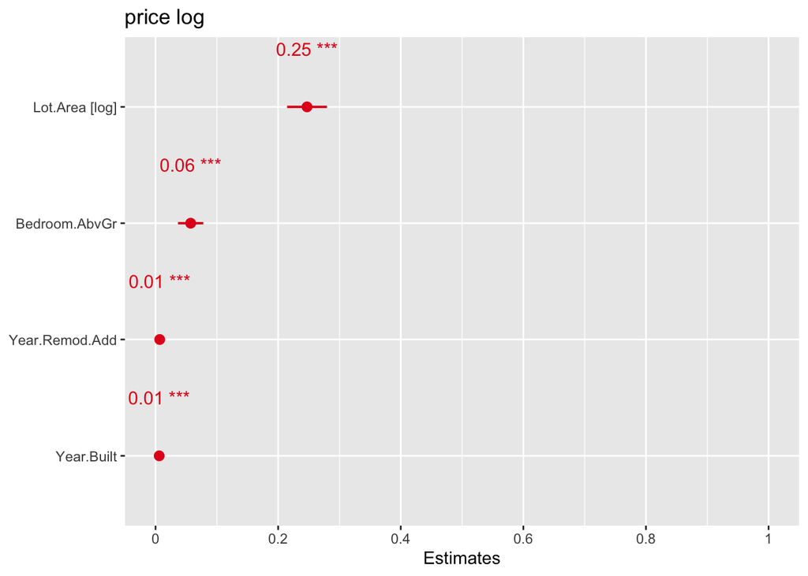

```r
library(sjPlot)
plot_model(fit4, vline.color = "red", sort.est = TRUE, show.values = TRUE, value.offset = .5)
```

By using log(Lot.Area), the stepAIC considering the BIC gives us a new model with less factors. The new selected model removed the factor Land.Slope: * price_log ~ log(Lot.Area) + Year.Built + Year.Remod.Add + Bedroom.AbvGr

While the BIC is better than the full model, the Adjusted R-squared also is better: increased to 0.6015.

# 7

Do you think it is better to log transform Lot.Area, in terms of assumptions for linear regression? Make graphs of the predicted values of log home price versus the true values of log home price for the regression models selected for Lot.Area and log(Lot.Area). Referencing these two plots, provide a written support that includes a quantitative justification for your answer in the first part of question 7.

```r
# type your code for Question 7 here, and Knit
y2 <- data.frame(Observed = ames_train$price_log, Predicted = fitted(fit2))
p2 <- ggplot(y2, aes(x=Observed, y=Predicted)) + geom_point() + stat_smooth(method = "lm", col = "red") + ggtitle("Lot.Area")
BIC(fit2)
```

```
## [1] 333.3642
```

```r
y4 <- data.frame(Observed = ames_train$price_log, Predicted = fitted(fit4))
p4 <- ggplot(y4, aes(x=Observed, y=Predicted)) + geom_point() + stat_smooth(method = "lm", col = "red") + ggtitle("Log(Lot.Area)")
BIC(fit4)
```

```
## [1] 222.1599
```

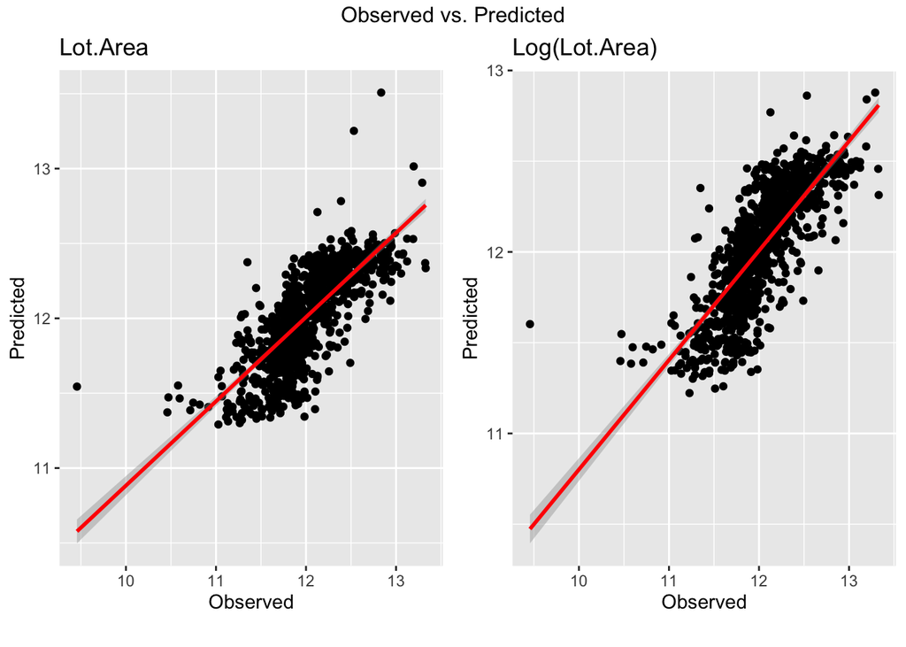

```r
grid.arrange(
  p2, p4,
  nrow = 1,
  top = "Observed vs. Predicted",
  bottom = textGrob(
    "",
    gp = gpar(fontface = 3, fontsize = 9),
    hjust = 1,
    x = 1
  )
)
```

By analysing the two graphics, we can see that log-transforming the Lot.Area gives us a better model fit since the dots in the graphic on the right are closer and better distributed along the fitted line.

By log-transforming Lot.Area, we have improved the Adjusted R-squared, making it 0.6015 instead of 0.5598.

### 7.0.1